# Detecting Exoplanets amongst Kepler Objects of Interest

# Introduction

Extrosolar planets may be discovered by two commonly-used methods: the first (the transit method) involves detecting the exoplanet as it partially eclipses host star, and the second (the radial velocity method) involves detecting the host star’s “wobble” around its planetary system’s center of mass. Potential such host stars are referred to as “Kepler objects of interest”. The data given to us contains information on a set of 9177 Kepler objects of interest, with 18 predictor variables that measure aspects related to exoplanets, host stars, exoplanet orbits, and transit, and a response variable that states for each observation if we have detected a confirmed exoplanet (“CONFIRMED”), have not identified an exoplanet (“FALSE POSITIVE”), or are unsure of the nature of what we have detected (“CANDIDATE”). The descriptions of the predictors are given below:

Predictors in our Dataset

| Names | Descriptions |
| --- | --- |
| koi_period | The interval between consecutive planetary transits |
| koi_eccen | Eccentricity value of the exoplanet (i.e. the ratio of the distance from the center to the foci and the distance from the center to the vertices) |
| koi_impact | The sky-projected distance between the center of the stellar disc and the center of the planet disc at conjunction, normalized by the stellar radius |
| koi_duration | The duration of the observed transits |
| koi_depth | The fraction of stellar flux lost at the minimum of the planetary transit |
| koi_ror | The planet radius divided by the stellar radius |
| koi_srho | The fitted stellar density |
| koi_prad | The radius of the planet |
| koi_sma | Half of the long axis of the ellipse defining a planet’s orbit |
| koi_incl | The angle between the plane of the sky (perpendicular to the line of sight) and the orbital plane of the planet candidate |
| koi_teq | Approximation for the temperature of the planet |
| koi_insol | The insolation flux |
| koi_dor | The distance between the planet and the star at mid-transit divided by the stellar radius |
| koi_steff | The photospheric temperature of the star |
| koi_slogg | The base-10 logarithm of the acceleration due to gravity at the surface of the star |
| koi_smet | The base-10 logarithm of the Fe to H ratio at the surface of the star, normalized by the solar Fe to H ratio |
| koi_srad | The photospheric radius of the star |
| koi_smass | The mass of the star |

Our aim is to identify a model that may be trained in order to effectively differentiate between “CONFIRMED” and “FALSE POSITIVE” exoplanetary candidates. We will attempt 6 models - logistic regression, linear discriminant analysis, classification tree, random forest, Naive bayes, and XGBoost - and will select the one with the best performance to apply to our candidate data.

# Summary of given data

Firstly, looking at our dataset, it appears that koi_eccen has only zeroes in it, so we may remove this predictor as it will likely not contribute much to our analysis. Next, we must remove the rows which have a response of “CANDIDATE” from our dataset as we are only interested in predicting our responses as either “CONFIRMED” or “FALSE POSITIVE”. We will also split our data into test and training sets, keeping 80% of the data in our training set and the other portion in our test set.

Now, we will conduct a summary of our dataset.

```
##    koi_period          koi_impact        koi_duration
##  Min.   :   0.2418   Min.   :  0.0000   Min.   :  0.1046
##  1st Qu.:   2.1132   1st Qu.:  0.2330   1st Qu.:  2.5379
##  Median :   7.4427   Median :  0.5920   Median :  3.9085
##  Mean   :  50.8026   Mean   :  0.7632   Mean   :  5.8514
##  3rd Qu.:  27.5014   3rd Qu.:  0.9220   3rd Qu.:  6.3490
##  Max.   :1071.2326   Max.   :100.8060   Max.   :138.5400
##    koi_depth            koi_ror            koi_srho
##  Min.   :      0.8   Min.   : 0.00129   Min.   :  0.0000
##  1st Qu.:    181.9   1st Qu.: 0.01320   1st Qu.:  0.1777
##  Median :    512.6   Median : 0.02453   Median :  0.7595
##  Mean   :  31492.3   Mean   : 0.30180   Mean   :  6.9371
##  3rd Qu.:   3031.6   3rd Qu.: 0.21976   3rd Qu.:  2.3885
##  Max.   :1541400.0   Max.   :99.87065   Max.   :980.8542
##     koi_prad            koi_sma          koi_incl        koi_teq
##  Min.   :     0.08   Min.   :0.0059   Min.   : 2.29   Min.   :   92.0
##  1st Qu.:     1.51   1st Qu.:0.0320   1st Qu.:81.37   1st Qu.:  583.5
##  Median :     2.71   Median :0.0741   Median :87.89   Median :  955.0
##  Mean   :   109.93   Mean   :0.1919   Mean   :80.81   Mean   : 1177.7
##  3rd Qu.:    26.82   3rd Qu.:0.1763   3rd Qu.:89.62   3rd Qu.: 1531.0
##  Max.   :200346.00   Max.   :2.1525   Max.   :90.00   Max.   :14667.0
##    koi_insol           koi_dor           koi_steff       koi_slogg
##  Min.   :       0   Min.   :   0.386   Min.   : 2661   Min.   :0.047
##  1st Qu.:      27   1st Qu.:   4.053   1st Qu.: 5325   1st Qu.:4.204
##  Median :     197   Median :  12.220   Median : 5780   Median :4.438
##  Mean   :    9897   Mean   :  55.334   Mean   : 5730   Mean   :4.304
##  3rd Qu.:    1298   3rd Qu.:  34.700   3rd Qu.: 6130   3rd Qu.:4.542
##  Max.   :10947555   Max.   :2421.700   Max.   :15896   Max.   :5.283
##     koi_smet          koi_srad         koi_smass                  y
##  Min.   :-2.5000   Min.   :  0.116   Min.   :0.094   CANDIDATE     :   0
##  1st Qu.:-0.2800   1st Qu.:  0.830   1st Qu.:0.844   CONFIRMED     :2296
##  Median :-0.1000   Median :  1.000   Median :0.974   FALSE POSITIVE:4563
##  Mean   :-0.1357   Mean   :  1.775   Mean   :1.029
##  3rd Qu.: 0.0600   3rd Qu.:  1.368   3rd Qu.:1.104
##  Max.   : 0.5600   Max.   :229.908   Max.   :3.686
```

Upon looking at the summary of the given data, we notice that there are significant differences between the mean and median values (with higher mean than median values) for the koi_period, koi_depth, koi_srho, koi_prad, koi_insol, koi_sma and koi_dor variables, indicating right skewness in the distribution for these variables. There also appear to be strong outliers for many of the variables (such as koi_period, koi_prad and koi_depth), indicated by the large differences between the maximum and third quartile values for these variables. The data for variables such as koi_smass, koi_steff and koi_slogg hints at symmetric distributions, shown by the closeness between their mean and median values.

# Univariate Analysis

Upon conducting our initial visualization, it was noticed that many of our predictor variables were significantly skewed. To ensure that our analysis is smoother, we may transform our right-skewed variables using log transformations.

## Orbit-related variables

We may begin by creating diagrams to observe the distribution of our variables. To start with, we will look at orbit-related variables (koi_dor, koi_period, koi_sma and koi_incl). Following our transformations, koi_dor, koi_period, and koi_sma appeared to have roughly symmetric distributions, so we will instead look closer at koi_incl.

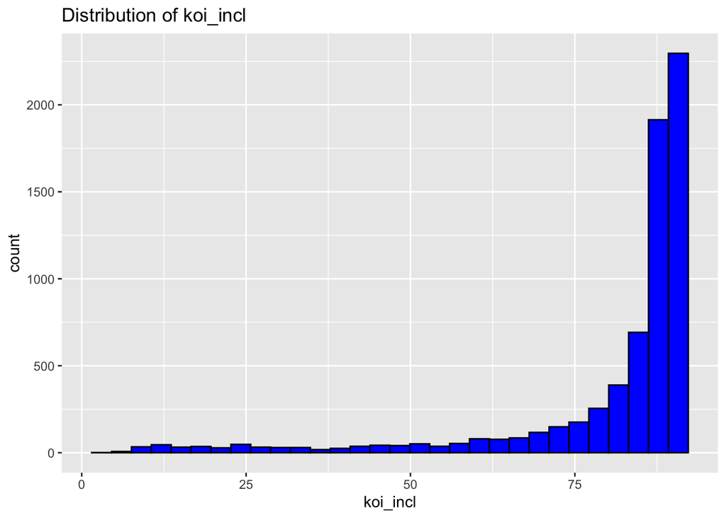

As shown above, koi_incl appears to have a significantly left-skewed and unimodal distribution.

## Transit/eclipse-related variables

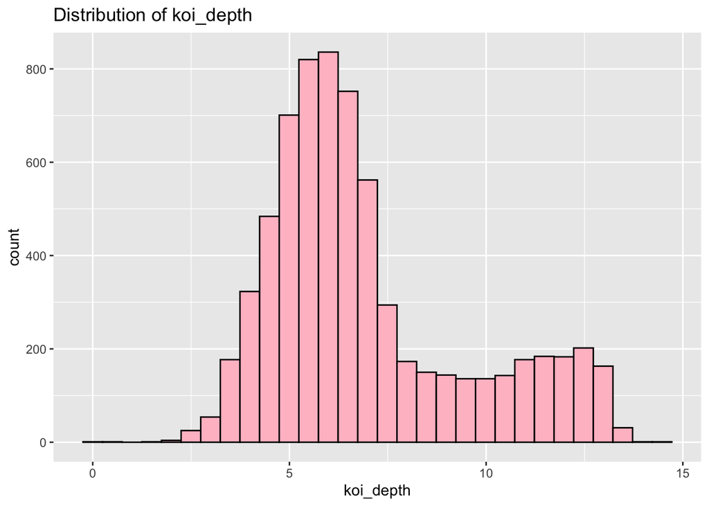

## Exoplanet property-related variables

Next, we may take a look at the exoplanet property-related variables, which are koi_ror, koi_prad, koi_teq and koi_insol. Focusing on koi_insol and koi_prad, we observe the following:

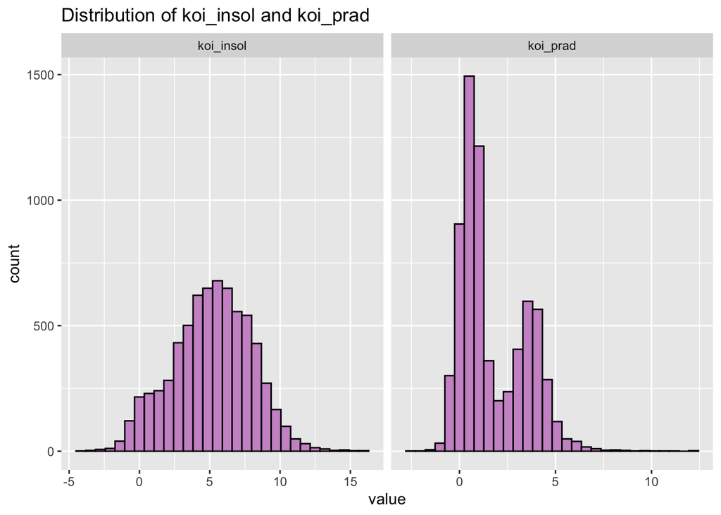

The distribution of koi_insol still appears to be symmetric and unimodal, while that for koi_prad appears to be somewhat symmetric and bimodal.

## Host star property-related variables

Finally, we may look at the distributions for the host star property-related variables (koi_srho, koi_steff, koi_slogg, koi_smet, koi_srad and koi_smass). Focusing on koi_srho, we observe the following:

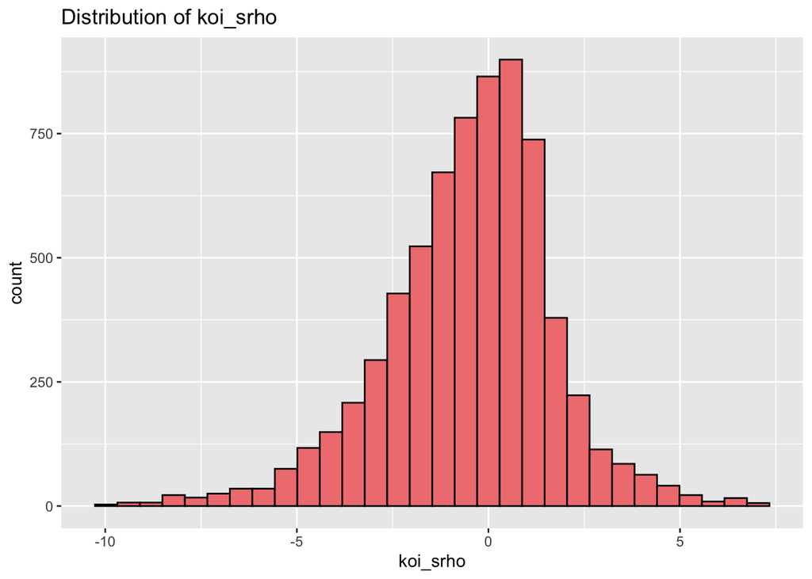

Our histogram indicates that koi_srho has a fairly symmetric and unimodal distribution, with the mode situated at roughly 0.

# Bivariate Analysis

Before going on to conduct principal components analysis, it is useful to identify if any of the variables are strongly correlated with one another so as to reduce our number of predictors. We can examine this by constructing a correlation plot for our data as shown below.

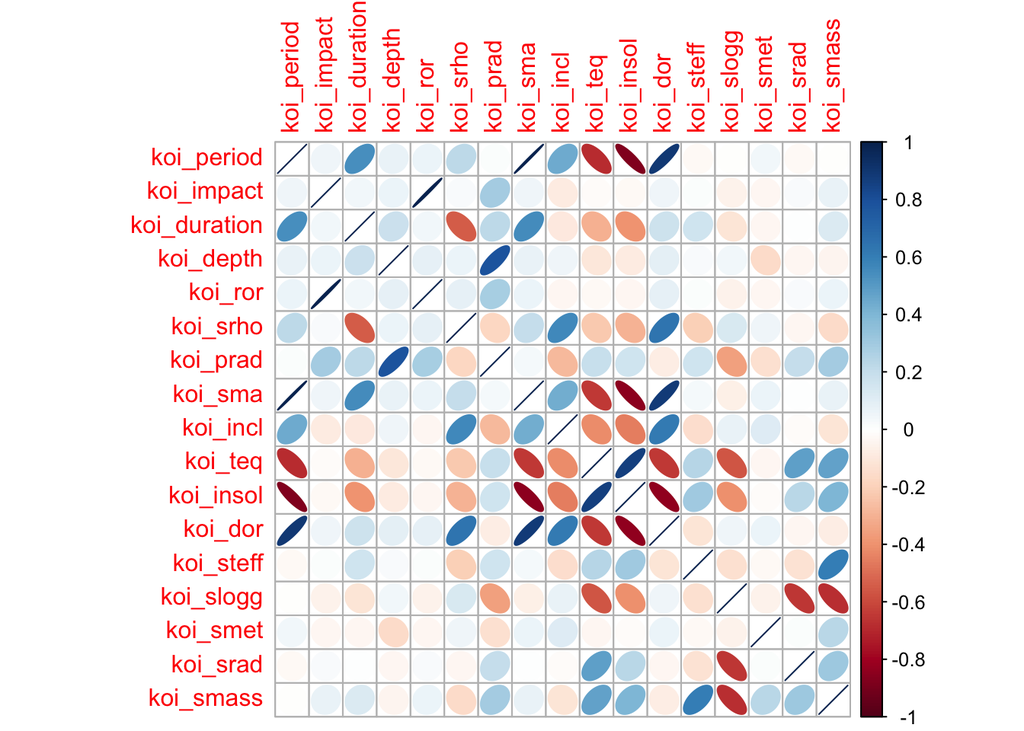

As shown by the correlation plot above, there appear to be especially strong positive correlations between koi_impact and koi_ror, koi_sma and koi_period, and fairly strong positive correlations between koi_dor and koi_period, koi_sma and koi_dor, and koi_insol and koi_teq. There also appear to be fairly strong negative correlations between koi_period and koi_insol, koi_insol and koi_sma, as well as between koi_insol and koi_dor.

We will observe the relationships between koi_impact and koi_ror, and between koi_sma and koi_period (as the positive correlation values between these variables were especially high), as well as the negative relationship between koi_period and koi_insol.

## Koi_ror vs. Koi_impact

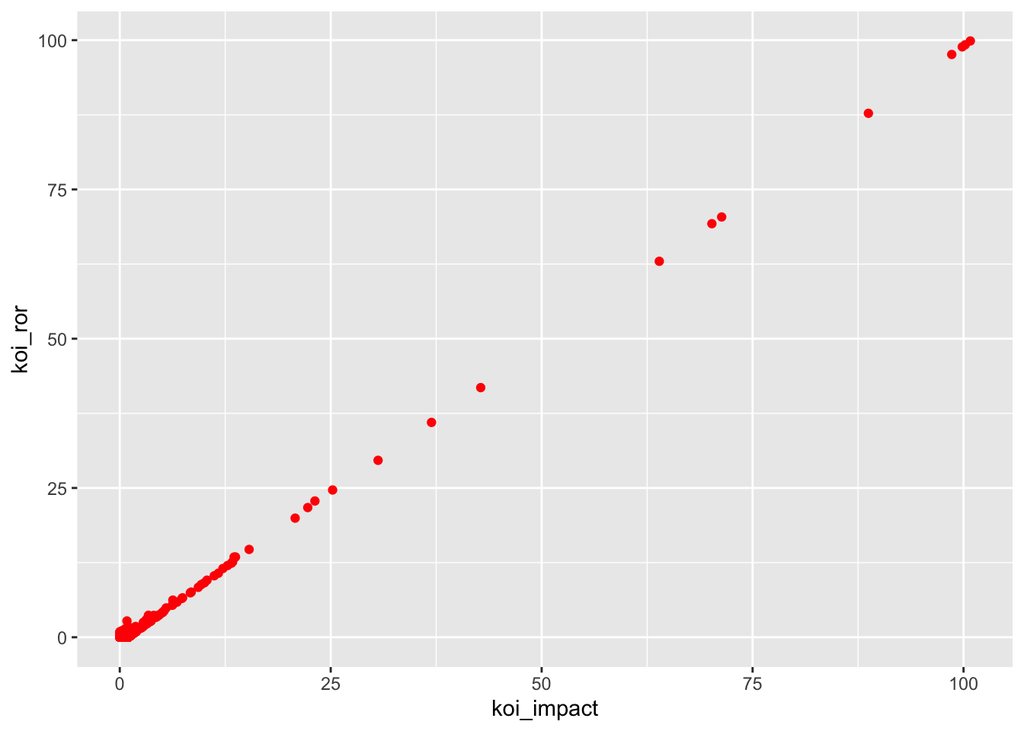

As shown by the scatterplot above, there appears to be a very strong positive relationship between koi_impact and koi_ror, with most of the data points occuring between 0 and around 12 (on both the y and x-axes). The relationship here appears to be rather deterministic, so it would be good for our analysis to remove one of the variables.

## Koi_period vs. Koi_sma

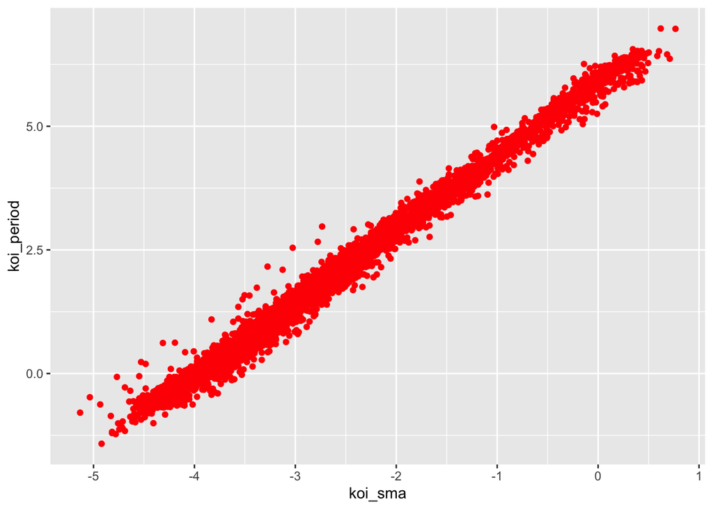

The scatterplot shown above suggests a strong positive linear relationship between the two variables, with values becoming slightly less clustered as koi_sma and koi_period increase. This relationship also appears to be somewhat deterministic, so we may remove one of these variables from our dataset.

## Koi_insol vs. Koi_period

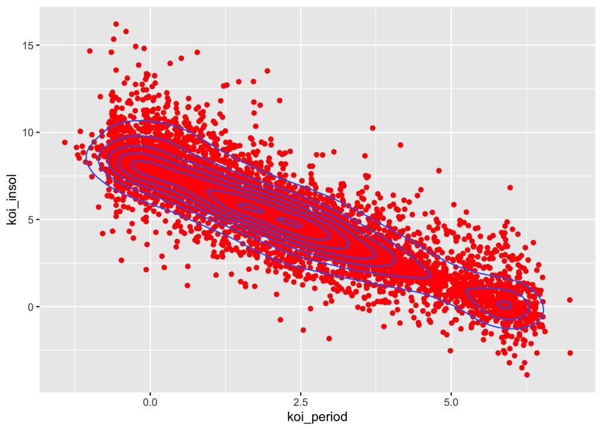

There appears to be a fairly strong negative relationship between koi_period and koi_insol.

Because of the very high correlation values between koi_impact and koi_ror and the rather deterministic relationship between the two, we will remove koi_ror. We will also remove koi_sma due to the deterministic relationship between koi_sma and koi_period.

# PC Analysis

Given that we have a large number of variables in our dataset, conducting PCA would give us an idea of whether we could reduce the dimensionality of our predictor space. The dominant predictors for each principal component have been displayed below.

Dominant Predictors for Principal Components

| Principle Component | Dominant Variable |
| --- | --- |
| PC1 | koi_insol |
| PC2 | koi_slogg |
| PC3 | koi_srho |
| PC4 | koi_depth |
| PC5 | koi_steff |
| PC6 | koi_impact |
| PC7 | koi_smet |
| PC8 | koi_incl |
| PC9 | koi_srad |
| PC10 | koi_srho |
| PC11 | koi_smass |
| PC12 | koi_teq |
| PC13 | koi_prad |
| PC14 | koi_insol |
| PC15 | koi_dor |

We may now construct a plot to observe the cumulative proportions of variance explained by our 15 principal components, so as to determine which ones we must retain:

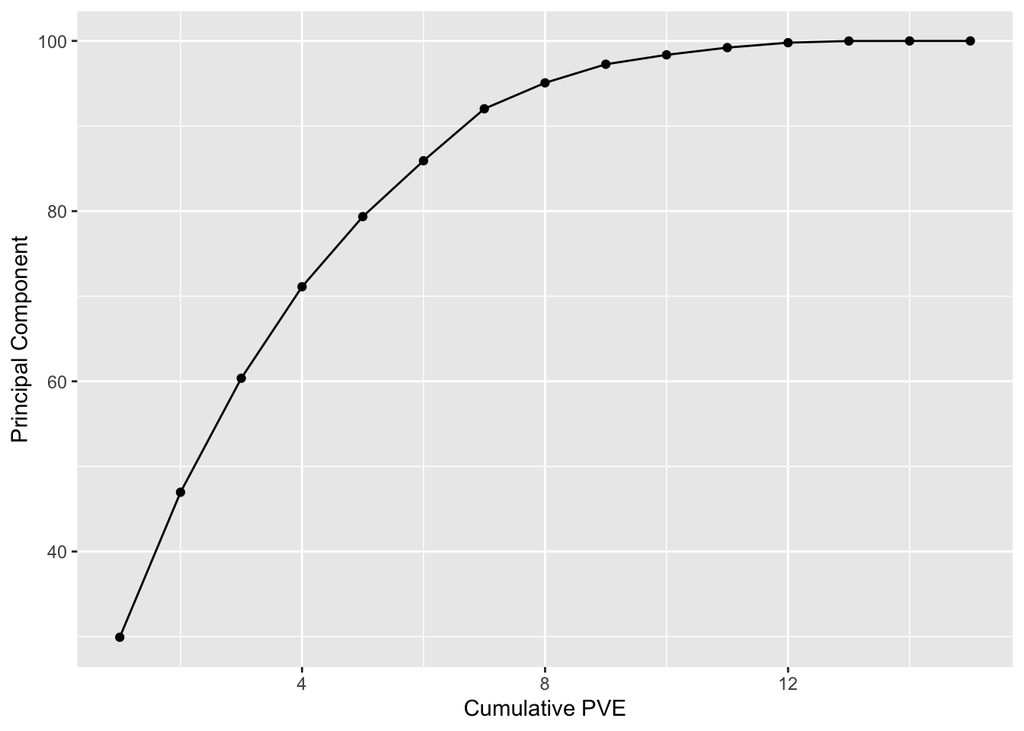

As shown above, approximately 90% of the variance is explained by the first 7 principal components, so we do not have much need to retain the other 8. This is validated by our summary of our PCA data, in which around 92.03% of the variance is explained by the first 7 principle components as shown below.

```
## Importance of components:
##                           PC1    PC2    PC3    PC4     PC5     PC6     PC7
## Standard deviation     2.1186 1.5988 1.4176 1.2701 1.11167 0.99253 0.95687
## Proportion of Variance 0.2992 0.1704 0.1340 0.1076 0.08239 0.06567 0.06104
## Cumulative Proportion  0.2992 0.4696 0.6036 0.7112 0.79354 0.85922 0.92026
##                           PC8     PC9    PC10    PC11   PC12    PC13
## Standard deviation     0.6764 0.57243 0.40720 0.35729 0.2949 0.17181
## Proportion of Variance 0.0305 0.02185 0.01105 0.00851 0.0058 0.00197
## Cumulative Proportion  0.9508 0.97260 0.98366 0.99217 0.9980 0.99993
##                           PC14      PC15
## Standard deviation     0.03195 0.0002105
## Proportion of Variance 0.00007 0.0000000
## Cumulative Proportion  1.00000 1.0000000
```

We may create a new dataset with only our 7 retained principal components (which we will use when conducting logistic regression analysis).

## Classification Analyses

We may now attempt to apply classifications models to our data, and observe which one has the strongest performance (by identifying which ones yield the lowest misclassification rate). We will also note the area under the curve values for the ROC curves of each of our models.

We will attempt 6 different analyses: logistic regression, linear discriminant analysis, classification tree, random forest, Naive bayes, and XGBoost.

### Logistic Regression

We can start with a logistic regression model:

```r
set.seed(101)
#Using our main training and test data
glm.out = glm(resp.train~., data = pred.train, family = binomial)
summary(glm.out)
```

```
##
## Call:
## glm(formula = resp.train ~ ., family = binomial, data = pred.train)
##
## Deviance Residuals:
##     Min       1Q   Median       3Q      Max
## -5.6752  -0.6083   0.0052   0.4654   2.7795
##
## Coefficients:
##                Estimate Std. Error z value Pr(>|z|)
## (Intercept)  -1.246e+02  1.211e+02  -1.029 0.303286
## koi_period   -6.795e+01  6.085e+01  -1.117 0.264104
## koi_impact    1.842e+00  2.597e-01   7.090 1.34e-12 ***
## koi_duration  5.644e+00  3.865e-01  14.602  < 2e-16 ***
## koi_depth    -3.850e+00  4.834e-01  -7.965 1.65e-15 ***
## koi_srho     -2.979e+01  3.043e+01  -0.979 0.327491
## koi_prad      7.537e+00  9.344e-01   8.066 7.25e-16 ***
## koi_incl     -1.355e-01  1.619e-02  -8.370  < 2e-16 ***
## koi_teq       4.819e-03  3.070e-04  15.697  < 2e-16 ***
## koi_insol    -3.132e+00  6.530e-01  -4.796 1.62e-06 ***
## koi_dor       9.497e+01  9.128e+01   1.040 0.298132
## koi_steff     2.056e-03  5.706e-04   3.603 0.000314 ***
## koi_slogg     6.803e+00  1.581e+00   4.303 1.69e-05 ***
## koi_smet     -3.118e+00  2.796e-01 -11.151  < 2e-16 ***
## koi_srad      1.531e+00  3.117e-01   4.913 8.97e-07 ***
## koi_smass    -2.663e+00  8.718e-01  -3.054 0.002255 **
## ---
## Signif. codes:  0 '***' 0.001 '**' 0.01 '*' 0.05 '.' 0.1 ' ' 1
##
## (Dispersion parameter for binomial family taken to be 1)
##
##     Null deviance: 7007.1  on 5486  degrees of freedom
## Residual deviance: 3733.1  on 5471  degrees of freedom
## AIC: 3765.1
##
## Number of Fisher Scoring iterations: 10
```

```r
resp.prob = predict(glm.out,newdata=pred.test,type="response")
roc.glm = roc(resp.test, resp.prob)
J = roc.glm$sensitivities + roc.glm$specificities - 1
w = which.max(J)
thresh = roc.glm$thresholds[w]
glm.sens = roc.glm$sensitivities[w]
glm.spec = roc.glm$specificities[w]
resp.pred = rep(NA,length(resp.prob))
for ( ii in 1:length(resp.prob) ) {
  if (resp.prob[ii] < thresh) {
    resp.pred[ii] = "CONFIRMED"
  } else {
    resp.pred[ii] = "FALSE POSITIVE"
  }
}
tb = table(resp.pred, resp.test)
tb
```

```
##                 resp.test
## resp.pred        CONFIRMED FALSE POSITIVE
##   CONFIRMED            411            164
##   FALSE POSITIVE        40            757
```

```r
mcr.glm = 1-sum(tb[1,1], tb[2,2])/sum(tb[1,1], tb[1,2], tb[2,1], tb[2,2])
```

| MCR (in percent) | AUC |
| --- | --- |
| 14.9 | 0.9209 |

```r
#Using our PCA training and test data
set.seed(101)
glm.out.pca = glm(resp.train~., data = pca.pred.train, family = binomial)
summary(glm.out.pca)
```

```
##
## Call:
## glm(formula = resp.train ~ ., family = binomial, data = pca.pred.train)
##
## Deviance Residuals:
##     Min       1Q   Median       3Q      Max
## -3.2394  -0.8345   0.2360   0.7189   2.8168
##
## Coefficients:
##             Estimate Std. Error z value Pr(>|z|)
## (Intercept)  1.44209    0.05420  26.605   <2e-16 ***
## PC1          0.61720    0.02865  21.546   <2e-16 ***
## PC2         -0.93358    0.04541 -20.560   <2e-16 ***
## PC3         -0.59659    0.04907 -12.158   <2e-16 ***
## PC4          0.94206    0.05307  17.752   <2e-16 ***
## PC5          0.01868    0.06461   0.289    0.773
## PC6         -2.01791    0.20304  -9.938   <2e-16 ***
## PC7          1.39287    0.06721  20.724   <2e-16 ***
## ---
## Signif. codes:  0 '***' 0.001 '**' 0.01 '*' 0.05 '.' 0.1 ' ' 1
##
## (Dispersion parameter for binomial family taken to be 1)
##
##     Null deviance: 7007.1  on 5486  degrees of freedom
## Residual deviance: 4906.4  on 5479  degrees of freedom
## AIC: 4922.4
##
## Number of Fisher Scoring iterations: 6
```

```r
resp.prob.pca = predict(glm.out.pca,newdata=pca.pred.test,type="response")
pca.roc.glm = roc(resp.test, resp.prob.pca)
J = roc.glm$sensitivities + roc.glm$specificities - 1
w = which.max(J)
thresh = roc.glm$thresholds[w]
pca.glm.sens = pca.roc.glm$sensitivities[w]
pca.glm.spec = pca.roc.glm$specificities[w]
resp.pred.pca = rep(NA,length(resp.prob.pca))
for ( ii in 1:length(resp.prob.pca) ) {
  if (resp.prob.pca[ii] < thresh) {
    resp.pred.pca[ii] = "CONFIRMED"
  } else {
    resp.pred.pca[ii] = "FALSE POSITIVE"
  }
}
tb.pca = table(resp.pred.pca, resp.test)
tb.pca
```

```
##                 resp.test
## resp.pred.pca    CONFIRMED FALSE POSITIVE
##   CONFIRMED            353            220
##   FALSE POSITIVE        98            701
```

```r
mcr.glm.pca = 1-sum(tb.pca[1,1], tb.pca[2,2])/sum(tb.pca[1,1], tb.pca[1,2], tb.pca[2,1], tb.pca[2,2])
```

| MCR (in percent) | AUC |
| --- | --- |
| 23.2 | 0.8457 |

Since our MCR for logistic regression conducted on our regular training and test data (14.9%) is significantly lower than the MCR we receive when we conduct logistic regression on the training and test data we obtained through PCA (23.2%), we can continue to use our regular data when trying out potential models. Furthermore, we also observe that the AUC for logistic regression conducted on our regular training and test data is 0.9209, but only 0.8457 for logistic regression conducted on our PCA data.

### Linear Discriminant Analysis

Next, we can attempt to conduct a linear discriminant analysis:

```
##                 resp.test
## resp.pred.lda    CONFIRMED FALSE POSITIVE
##   CONFIRMED            416            283
##   FALSE POSITIVE        35            638
```

| MCR (in percent) | AUC |
| --- | --- |
| 23.2 | 0.8749 |

Our LDA analysis gives us a misclassification rate of approximately 23.2%, which is higher than what we received for logistic regression. We also receive a lower AUC of only 0.8749, so we will not use this model.

### Classification Tree

Next, we may attempt to generate a classification tree.

```
##                 resp.test
## resp.pred.tree   CONFIRMED FALSE POSITIVE
##   CONFIRMED            413            124
##   FALSE POSITIVE        38            797
```

| MCR (in percent) | AUC |
| --- | --- |
| 11.8 | 0.9117 |

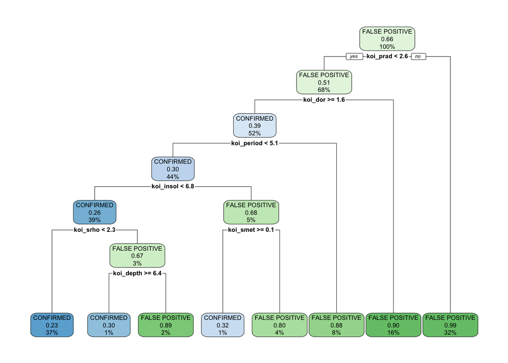

According to our classification tree, the dominant predictors appear to be koi_prad, koi_dor, koi_period, koi_insol, koi_srho, koi_smet, and koi_depth.

Our misclassification rate with this model is approximately 11.8%, which is somewhat lower than that yielded by our logistic regression model. Our ROC curve yields an AUC value of 0.9117.

### Random Forest

Now, we will use a random forest model.

```
##                 resp.test
## resp.pred.rf     CONFIRMED FALSE POSITIVE
##   CONFIRMED            429             78
##   FALSE POSITIVE        22            843
```

| MCR (in percent) | AUC |
| --- | --- |
| 7.3 | 0.9757 |

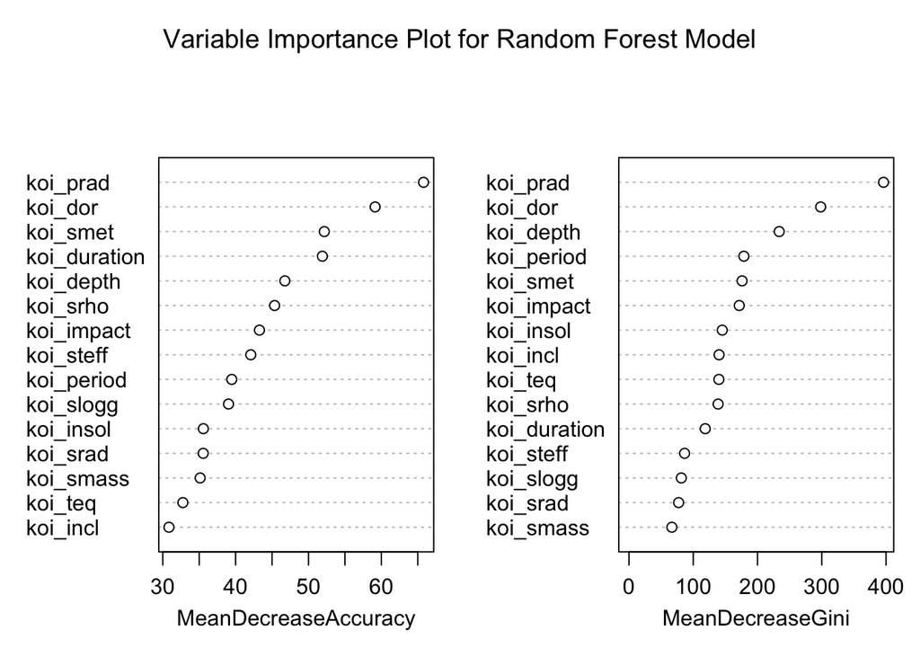

Upon using a variable importance plot, we see that koi_prad and koi_dor seem to hold the highest amount of importance amongst the predictor variables.

### Naive Bayes

We may now attempt to use a Naive Bayes classifier on our data.

```
##                 resp.test
## resp.pred.naive  CONFIRMED FALSE POSITIVE
##   CONFIRMED            391            123
##   FALSE POSITIVE        60            798
```

| MCR (in percent) | AUC |
| --- | --- |
| 13.3 | 0.9255 |

Our resulting MCR is 13.3%, while our AUC is 0.9255.

### XGBoost

Lastly, we may now try to use the XGBoost algorithm.

```
##                 resp.test
## resp.pred.xg     CONFIRMED FALSE POSITIVE
##   CONFIRMED            432             95
##   FALSE POSITIVE        19            826
```

| MCR (in percent) | AUC |
| --- | --- |
| 8.3 | 0.9673 |

Our XGBoost algorithm yields a low MCR of 8.3% and a fairly high AUC value of 0.9673. However, these results are not as good as what we received using our random forest algorithm, so we will use our random forest model to make our final predictions.

Upon attempting ridge regression and lasso analyses, misclassification rates of 15% and 12% respectively were observed. Since these were both higher than for some of our other models, these models were discarded. Best subset selection was also considered, but due to the considerably large sample size of our data, it was too computationally inefficient to execute.

## Conclusion

After attempting to fit six potential models to our data, namely logistic regression, a classification tree, linear discriminant analysis, Naive Bayes, XGBoost, and random forest analysis, we found that using a random forest model on our data yielded the lowest misclassification rate, the highest AUC, and the highest sensitivity (as shown below). The resulting ROC curve for this model has also been displayed. This suggests to us that a random forest model is likely the best possible option that would allow us to effectively categorize our data points as either “CONFIRMED” or “FALSE POSITIVE”.

Performance across Classifiers

| Name of Model | MCR (in percent) | AUC (in percent) | Sensitivity (in percent) | Specificity (in percent) |
| --- | --- | --- | --- | --- |
| Logistic Regression | 14.9 | 92.1 | 82.2 | 91.1 |
| Logistic Regression with PCA Data | 23.2 | 84.6 | 76.1 | 78.7 |
| Classification Tree | 11.8 | 91.2 | 86.5 | 91.6 |
| LDA Analysis | 23.2 | 87.5 | 69.3 | 92.2 |
| Random Forest Analysis | 7.3 | 97.6 | 91.5 | 95.1 |
| Naive Bayes | 13.3 | 92.6 | 86.6 | 86.7 |
| XGBoost | 8.3 | 96.7 | 89.7 | 95.8 |

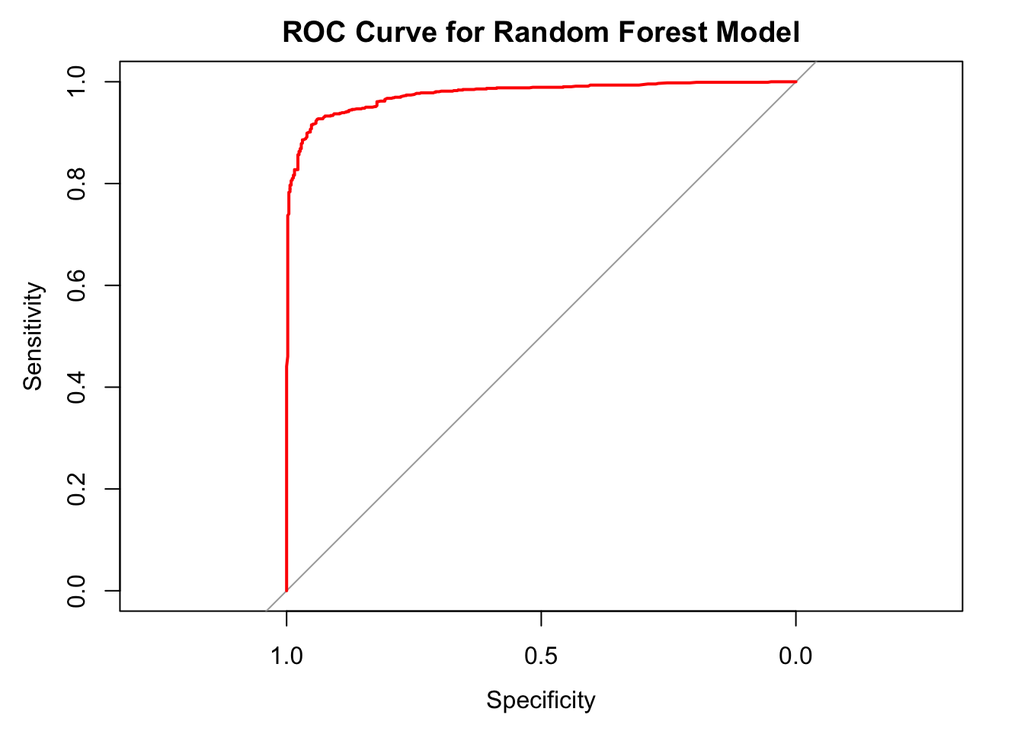

# Making Predictions

We will now use our random forest model to generate predictions for our CANDIDATE data.

```
## pred.candidate
##      CONFIRMED FALSE POSITIVE
##            838           1479
```

As indicated above, it appears that our model has classified 838 candidates as having confirmed exoplanets, and 1479 candidates as ‘false positive’ observations (i.e. not having exoplanets).